# Week1

# Data Visualization:

## simple scatter plot of the number of girls birth record per year using ggplot

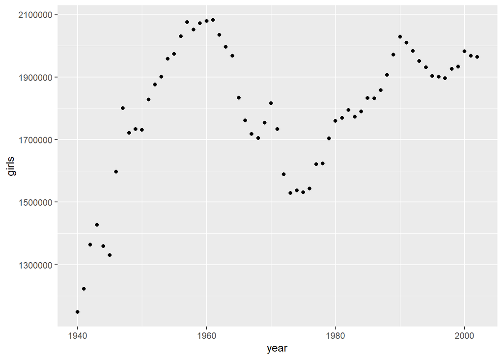

```r
ggplot(data = present, aes(x = year, y = girls)) +
  geom_point()
```

## simple line plot of the number of girls birth record per year in US using ggplot

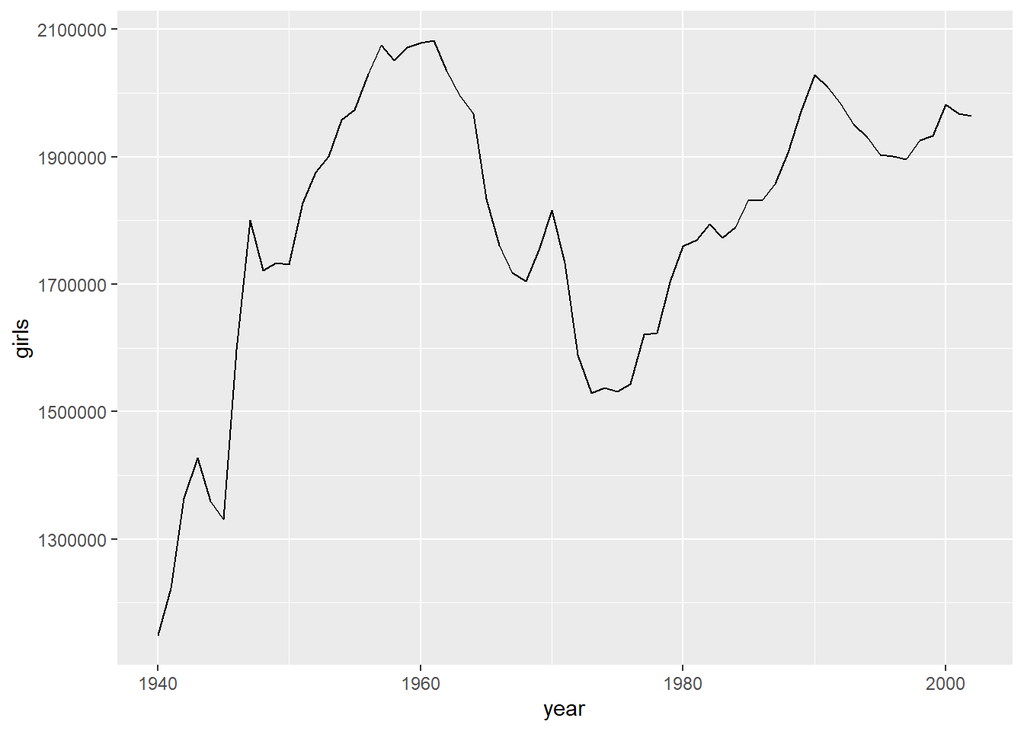

```r
ggplot(data = present, aes(x = year, y = girls)) +
  geom_line()
```

## Exercise 2: From 1940 to 1960 there is increase in the number of girls born per year. ## Then from 1980 to 2000 there is a increase in the number of girls born per year.

```r
present$boys + present$girls
```

```
##  [1] 2360399 2513427 2808996 2936860 2794800 2735456 3288672 3699940 3535068
## [10] 3559529 3554149 3750850 3846986 3902120 4017362 4047295 4163090 4254784
## [19] 4203812 4244796 4257850 4268326 4167362 4098020 4027490 3760358 3606274
## [28] 3520959 3501564 3600206 3731386 3555970 3258411 3136965 3159958 3144198
## [37] 3167788 3326632 3333279 3494398 3612258 3629238 3680537 3638933 3669141
## [46] 3760561 3756547 3809394 3909510 4040958 4158212 4110907 4065014 4000240
## [55] 3952767 3899589 3891494 3880894 3941553 3959417 4058814 4025933 4021726
```

## Adding a new variable to the dataframe

```r
present <- present %>%
  mutate(total = boys + girls)
present
```

```
## # A tibble: 63 x 4
##     year    boys   girls   total
##    <dbl>   <dbl>   <dbl>   <dbl>
##  1  1940 1211684 1148715 2360399
##  2  1941 1289734 1223693 2513427
##  3  1942 1444365 1364631 2808996
##  4  1943 1508959 1427901 2936860
##  5  1944 1435301 1359499 2794800
##  6  1945 1404587 1330869 2735456
##  7  1946 1691220 1597452 3288672
##  8  1947 1899876 1800064 3699940
##  9  1948 1813852 1721216 3535068
## 10  1949 1826352 1733177 3559529
## # ... with 53 more rows
```

## Exercise 3: To generate a plot of the proportion of boys born over time

```r
present <- present %>%
  mutate(boy_ratio = boys/total)
present
```

```
## # A tibble: 63 x 5
##     year    boys   girls   total boy_ratio
##    <dbl>   <dbl>   <dbl>   <dbl>     <dbl>
##  1  1940 1211684 1148715 2360399     0.513
##  2  1941 1289734 1223693 2513427     0.513
##  3  1942 1444365 1364631 2808996     0.514
##  4  1943 1508959 1427901 2936860     0.514
##  5  1944 1435301 1359499 2794800     0.514
##  6  1945 1404587 1330869 2735456     0.513
##  7  1946 1691220 1597452 3288672     0.514
##  8  1947 1899876 1800064 3699940     0.513
##  9  1948 1813852 1721216 3535068     0.513
## 10  1949 1826352 1733177 3559529     0.513
## # ... with 53 more rows
```

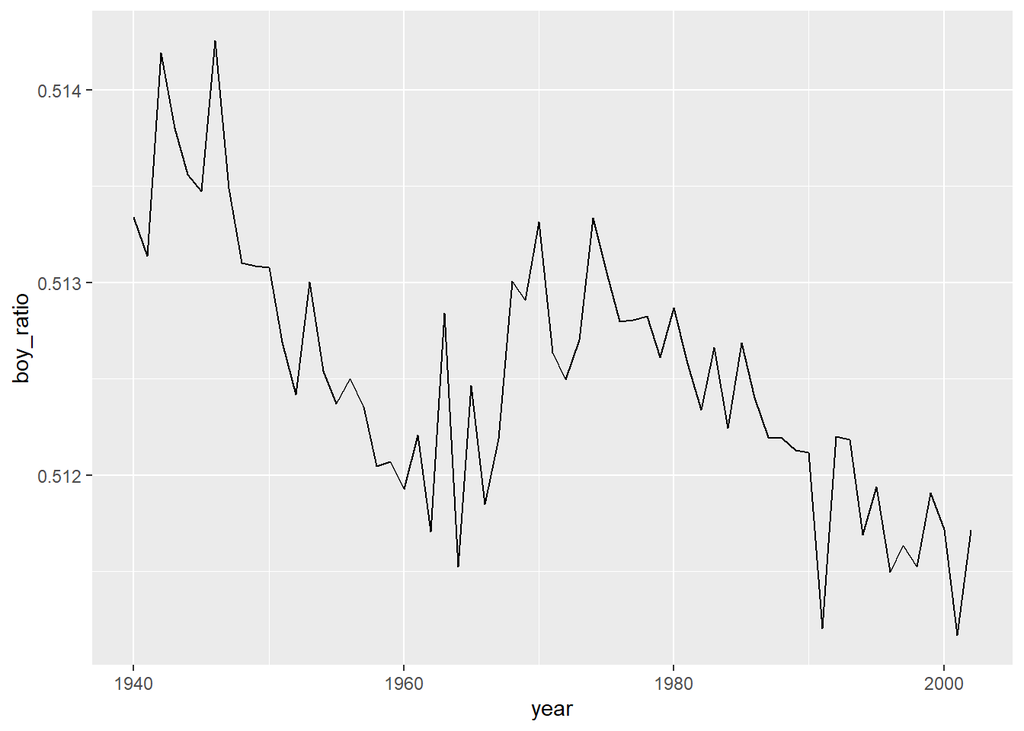

```r
ggplot(data = present, aes(x = year, y = boy_ratio)) +
  geom_line()
```

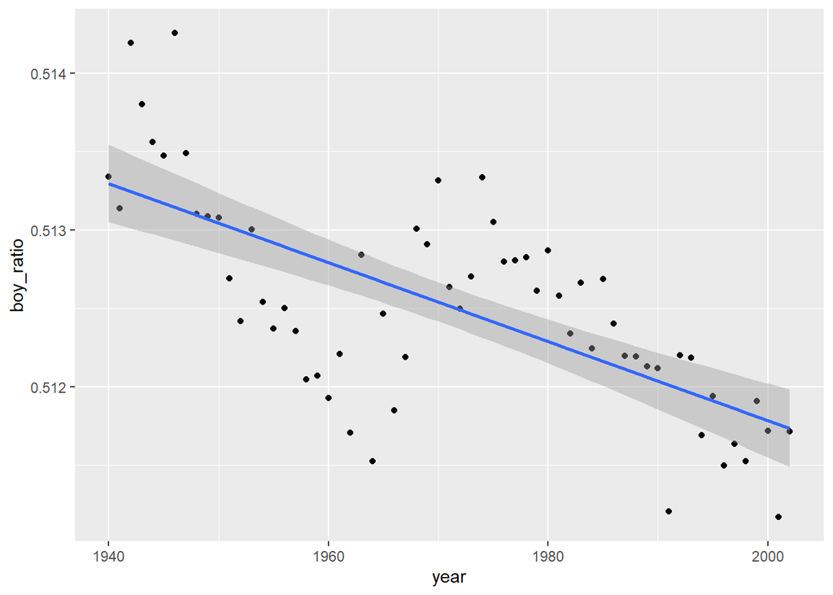

```r
ggplot(data = present, aes(x = year, y = boy_ratio)) +
  geom_point() +
  geom_smooth(method=lm) # add linear trend line
```

```r
# boys birth ratio per year is a downward slope from 1940 to 2000
```

```r
present <- present %>%
  mutate(boy_to_girl_ratio = boys / girls)
present
```

```
## # A tibble: 63 x 6
##     year    boys   girls   total boy_ratio boy_to_girl_ratio
##    <dbl>   <dbl>   <dbl>   <dbl>     <dbl>             <dbl>
##  1  1940 1211684 1148715 2360399     0.513              1.05
##  2  1941 1289734 1223693 2513427     0.513              1.05
##  3  1942 1444365 1364631 2808996     0.514              1.06
##  4  1943 1508959 1427901 2936860     0.514              1.06
##  5  1944 1435301 1359499 2794800     0.514              1.06
##  6  1945 1404587 1330869 2735456     0.513              1.06
##  7  1946 1691220 1597452 3288672     0.514              1.06
##  8  1947 1899876 1800064 3699940     0.513              1.06
##  9  1948 1813852 1721216 3535068     0.513              1.05
## 10  1949 1826352 1733177 3559529     0.513              1.05
## # ... with 53 more rows
```

## To see the boolean output if the boys are more than girls

```r
present <- present %>%
  mutate(more_boys = boys > girls)
present
```

```
## # A tibble: 63 x 7
##     year    boys   girls   total boy_ratio boy_to_girl_ratio more_boys
##    <dbl>   <dbl>   <dbl>   <dbl>     <dbl>             <dbl> <lgl>
##  1  1940 1211684 1148715 2360399     0.513              1.05 TRUE
##  2  1941 1289734 1223693 2513427     0.513              1.05 TRUE
##  3  1942 1444365 1364631 2808996     0.514              1.06 TRUE
##  4  1943 1508959 1427901 2936860     0.514              1.06 TRUE
##  5  1944 1435301 1359499 2794800     0.514              1.06 TRUE
##  6  1945 1404587 1330869 2735456     0.513              1.06 TRUE
##  7  1946 1691220 1597452 3288672     0.514              1.06 TRUE
##  8  1947 1899876 1800064 3699940     0.513              1.06 TRUE
##  9  1948 1813852 1721216 3535068     0.513              1.05 TRUE
## 10  1949 1826352 1733177 3559529     0.513              1.05 TRUE
## # ... with 53 more rows
```

```r
present %>%
  summarize(min = min(boys), max = max(boys))
```

```
## # A tibble: 1 x 2
##       min     max
##     <dbl>   <dbl>
## 1 1211684 2186274
```

# Exercise 4:

## What years are included in this data set?

```r
present$year
```

```
##  [1] 1940 1941 1942 1943 1944 1945 1946 1947 1948 1949 1950 1951 1952 1953 1954
## [16] 1955 1956 1957 1958 1959 1960 1961 1962 1963 1964 1965 1966 1967 1968 1969
## [31] 1970 1971 1972 1973 1974 1975 1976 1977 1978 1979 1980 1981 1982 1983 1984
## [46] 1985 1986 1987 1988 1989 1990 1991 1992 1993 1994 1995 1996 1997 1998 1999
## [61] 2000 2001 2002
```

# Exercise 4:

## How to get dimensions of a dataframe

```r
glimpse(present)
```

```
## Rows: 63
## Columns: 7
## $ year              <dbl> 1940, 1941, 1942, 1943, 1944, 1945, 1946, 1947, 1948~
## $ boys              <dbl> 1211684, 1289734, 1444365, 1508959, 1435301, 1404587~
## $ girls             <dbl> 1148715, 1223693, 1364631, 1427901, 1359499, 1330869~
## $ total             <dbl> 2360399, 2513427, 2808996, 2936860, 2794800, 2735456~
## $ boy_ratio         <dbl> 0.5133386, 0.5131376, 0.5141926, 0.5138001, 0.513561~
## $ boy_to_girl_ratio <dbl> 1.054817, 1.053969, 1.058429, 1.056767, 1.055757, 1.~
## $ more_boys         <lgl> TRUE, TRUE, TRUE, TRUE, TRUE, TRUE, TRUE, TRUE, TRUE~
```

```r
dim(present)
```

```
## [1] 63  7
```

# Exercise 4:

## What are the variable (column) names?

```r
colnames(present)
```

```
## [1] "year"              "boys"              "girls"
## [4] "total"             "boy_ratio"         "boy_to_girl_ratio"
## [7] "more_boys"
```

# Exercise 5:

## How do these counts compare to Arbuthnot’s? Are they of a similar magnitude?

## As you can see there is amajor difference in the magnitude of means

```r
# arbuthnot data mean is:
mean(arbuthnot$boys + arbuthnot$girls)
```

```
## [1] 11441.74
```

```r
# present data mean is:
mean(present$boys + present$girls)
```

```
## [1] 3679515
```

# Exercise 6

# Make a plot that displays the proportion of boys born over time. What do you see?

# Does Arbuthnot’s observation about boys being born in greater proportion

# than girls hold up in the U.S.?

# Include the plot in your response

```r
present <- present %>%
  mutate(girl_ratio = girls/total)
present
```

```
## # A tibble: 63 x 8
##     year    boys   girls   total boy_ratio boy_to_girl_rat~ more_boys girl_ratio
##    <dbl>   <dbl>   <dbl>   <dbl>     <dbl>            <dbl> <lgl>          <dbl>
##  1  1940 1211684 1148715 2360399     0.513             1.05 TRUE           0.487
##  2  1941 1289734 1223693 2513427     0.513             1.05 TRUE           0.487
##  3  1942 1444365 1364631 2808996     0.514             1.06 TRUE           0.486
##  4  1943 1508959 1427901 2936860     0.514             1.06 TRUE           0.486
##  5  1944 1435301 1359499 2794800     0.514             1.06 TRUE           0.486
##  6  1945 1404587 1330869 2735456     0.513             1.06 TRUE           0.487
##  7  1946 1691220 1597452 3288672     0.514             1.06 TRUE           0.486
##  8  1947 1899876 1800064 3699940     0.513             1.06 TRUE           0.487
##  9  1948 1813852 1721216 3535068     0.513             1.05 TRUE           0.487
## 10  1949 1826352 1733177 3559529     0.513             1.05 TRUE           0.487
## # ... with 53 more rows
```

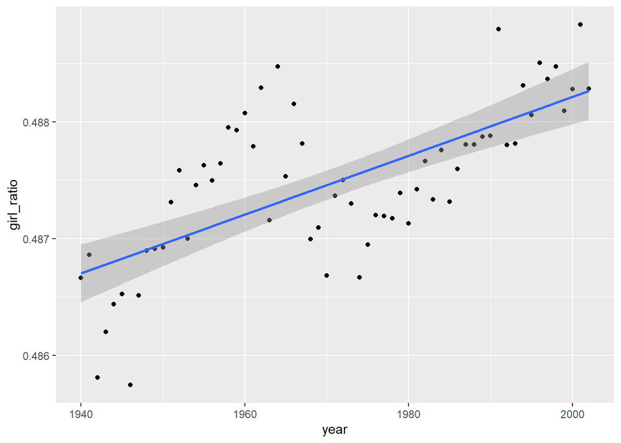

```r
ggplot(data = present, aes(x = year, y = girl_ratio)) +
  geom_point() +
  geom_smooth(method=lm) # add linear trend line
```

```r
# Analysis: you can see that the girls birth ratio increases from 1940 to 2000
# Whereas the boys birth ratio is decreasing from 1940 to 2000
```